# DOMAIN: Medical

• CONTEXT: Medical research university X is undergoing a deep research on patients with certain conditions. University has an internal AI team. Due to confidentiality the patient’s details and the conditions are masked by the client by providing different datasets to the AI team for developing a AIML model which can predict the condition of the patient depending on the received test results.

• DATA DESCRIPTION: The data consists of biomechanics features of the patients according to their current conditions. Each patient is represented in the data set by six biomechanics attributes derived from the shape and orientation of the condition to their body part.

• PROJECT OBJECTIVE: To Demonstrate the ability to fetch, process and leverage data to generate useful predictions by training Supervised Learning algorithms.

# 1.1 Data Understanding:

### Part 1. 1 a - Read all the 3 CSV files as DataFrame and store them into 3 separate variables.

```python
import pandas as pd
import numpy as np
import matplotlib.pyplot as plt
%matplotlib inline
import seaborn as sns
```

```python
ndata= pd.read_csv("Normal.csv")
hdata= pd.read_csv("Type_H.csv")
sdata= pd.read_csv("Type_S.csv")
```

### Part 1.1 b - Print Shape and columns of all the 3 DataFrames

```python
print("The size of normal data is {}".format(ndata.shape))
print("The size of Type_H data is {}".format(hdata.shape))
print("The size of Type_S data is {}".format(sdata.shape))
```

```
The size of normal data is (100, 7)
The size of Type_H data is (60, 7)
The size of Type_S data is (150, 7)
```

```python
print("The columns of normal data is {}".format(ndata.columns))
print("The columns of Type_H data is {}".format(hdata.columns))
print("The columns of Type_S data is {}".format(sdata.columns))
```

```
The columns of normal data is Index(['P_incidence', 'P_tilt', 'L_angle', 'S_slope', 'P_radius', 'S_Degree',
       'Class'],
      dtype='object')
The columns of Type_H data is Index(['P_incidence', 'P_tilt', 'L_angle', 'S_slope', 'P_radius', 'S_Degree',
       'Class'],
      dtype='object')
The columns of Type_S data is Index(['P_incidence', 'P_tilt', 'L_angle', 'S_slope', 'P_radius', 'S_Degree',
       'Class'],
      dtype='object')
```

```python
ndata.head()
```

|  | P_incidence | P_tilt | L_angle | S_slope | P_radius | S_Degree | Class |
| --- | --- | --- | --- | --- | --- | --- | --- |
| 0 | 38.505273 | 16.964297 | 35.112814 | 21.540976 | 127.632875 | 7.986683 | Normal |
| 1 | 54.920858 | 18.968430 | 51.601455 | 35.952428 | 125.846646 | 2.001642 | Normal |
| 2 | 44.362490 | 8.945435 | 46.902096 | 35.417055 | 129.220682 | 4.994195 | Normal |
| 3 | 48.318931 | 17.452121 | 48.000000 | 30.866809 | 128.980308 | -0.910941 | Normal |
| 4 | 45.701789 | 10.659859 | 42.577846 | 35.041929 | 130.178314 | -3.388910 | Normal |

```python
hdata.head()
```

|  | P_incidence | P_tilt | L_angle | S_slope | P_radius | S_Degree | Class |
| --- | --- | --- | --- | --- | --- | --- | --- |
| 0 | 63.027817 | 22.552586 | 39.609117 | 40.475232 | 98.672917 | -0.254400 | Type_H |
| 1 | 39.056951 | 10.060991 | 25.015378 | 28.995960 | 114.405425 | 4.564259 | Type_H |
| 2 | 68.832021 | 22.218482 | 50.092194 | 46.613539 | 105.985135 | -3.530317 | Type_H |
| 3 | 69.297008 | 24.652878 | 44.311238 | 44.644130 | 101.868495 | 11.211523 | Type_H |
| 4 | 49.712859 | 9.652075 | 28.317406 | 40.060784 | 108.168725 | 7.918501 | Type_H |

```python
sdata.head()
```

|  | P_incidence | P_tilt | L_angle | S_slope | P_radius | S_Degree | Class |
| --- | --- | --- | --- | --- | --- | --- | --- |
| 0 | 74.377678 | 32.053104 | 78.772013 | 42.324573 | 143.560690 | 56.125906 | Type_S |
| 1 | 89.680567 | 32.704435 | 83.130732 | 56.976132 | 129.955476 | 92.027277 | Type_S |
| 2 | 44.529051 | 9.433234 | 52.000000 | 35.095817 | 134.711772 | 29.106575 | Type_S |
| 3 | 77.690577 | 21.380645 | 64.429442 | 56.309932 | 114.818751 | 26.931841 | Type_S |
| 4 | 76.147212 | 21.936186 | 82.961502 | 54.211027 | 123.932010 | 10.431972 | Type_S |

### Part 1.1 c - Compare Column names of all the 3 DataFrames and clearly write observations

```python
pd.DataFrame({'ndata': ndata.shape, 'hdata': hdata.shape, 'sdata': sdata.shape}, index=['rows', 'columns'])
```

|  | ndata | hdata | sdata |
| --- | --- | --- | --- |
| rows | 100 | 60 | 150 |
| columns | 7 | 7 | 7 |

#### Observations: Columns are same with fluctuations in rows and there are 100 test as normal, 60 tests as Type_H and 150 tests as Type_S

### Part 1.1 d - Print DataTypes of all the 3 DataFrames.

```python
print("The DataTypes of normal data is {}".format(ndata.dtypes))
print("The DataTypes of Type_H data is {}".format(hdata.dtypes))
print("The DataTypes of Type_S data is {}".format(sdata.dtypes))
```

```
The DataTypes of normal data is P_incidence    float64
P_tilt         float64
L_angle        float64
S_slope        float64
P_radius       float64
S_Degree       float64
Class           object
dtype: object
The DataTypes of Type_H data is P_incidence    float64
P_tilt         float64
L_angle        float64
S_slope        float64
P_radius       float64
S_Degree       float64
Class           object
dtype: object
The DataTypes of Type_S data is P_incidence    float64
P_tilt         float64
L_angle        float64
S_slope        float64
P_radius       float64
S_Degree       float64
Class           object
dtype: object
```

### Part 1.1 e - Observe and share variation in ‘Class’ feature of all the 3 DataFrames

```python
ndata['Class'].value_counts()
```

```
Normal    73
Nrmal     27
Name: Class, dtype: int64
```

```python
hdata['Class'].value_counts()
```

```
Type_H    37
type_h    23
Name: Class, dtype: int64
```

```python
sdata['Class'].value_counts()
```

```
Type_S    133
tp_s       17
Name: Class, dtype: int64
```

#### So the representation of classes in words are different but the meaning is same where Nrmal has to be converted into Normal, type_h has to be converted into Type_H and tp_s has to be converted into Type_S. so we can get the perfect counts

# 1.2 Data Preparation and Exploration:

### Part 1.2 a - Unify all the variations in ‘Class’ feature for all the 3 DataFrames

```python
ndata.loc[ndata['Class']=='Nrmal','Class']='Normal'
hdata.loc[hdata['Class']=='type_h','Class']='Type_H'
sdata.loc[sdata['Class']=='tp_s','Class']='Type_S'
```

```python
ndata['Class'].value_counts()
```

```
Normal    100
Name: Class, dtype: int64
```

```python
hdata['Class'].value_counts()
```

```
Type_H    60
Name: Class, dtype: int64
```

```python
sdata['Class'].value_counts()
```

```
Type_S    150
Name: Class, dtype: int64
```

```python
#type of data is unified, now changing the dtype to categorical
ndata['Class']=ndata['Class'].astype('category')
hdata['Class']=hdata['Class'].astype('category')
sdata['Class']=sdata['Class'].astype('category')
```

### Part 1.2 b - Combine all the 3 DataFrames to form a single DataFrame

```python
alldata= ndata.append([hdata,sdata])
```

```python
alldata.shape #expectation matched
```

```
(310, 7)
```

```python
alldata.head()
```

|  | P_incidence | P_tilt | L_angle | S_slope | P_radius | S_Degree | Class |
| --- | --- | --- | --- | --- | --- | --- | --- |
| 0 | 38.505273 | 16.964297 | 35.112814 | 21.540976 | 127.632875 | 7.986683 | Normal |
| 1 | 54.920858 | 18.968430 | 51.601455 | 35.952428 | 125.846646 | 2.001642 | Normal |
| 2 | 44.362490 | 8.945435 | 46.902096 | 35.417055 | 129.220682 | 4.994195 | Normal |
| 3 | 48.318931 | 17.452121 | 48.000000 | 30.866809 | 128.980308 | -0.910941 | Normal |
| 4 | 45.701789 | 10.659859 | 42.577846 | 35.041929 | 130.178314 | -3.388910 | Normal |

```python
alldata['Class'].unique()
```

```
array(['Normal', 'Type_H', 'Type_S'], dtype=object)
```

### Part 1.2 c - Print 5 random samples of this DataFrame

```python
rows = alldata.sample(n = 5)
rows
```

|  | P_incidence | P_tilt | L_angle | S_slope | P_radius | S_Degree | Class |
| --- | --- | --- | --- | --- | --- | --- | --- |
| 11 | 86.900794 | 32.928168 | 47.794347 | 53.972627 | 135.075364 | 101.719092 | Type_S |
| 47 | 41.352504 | 16.577364 | 30.706191 | 24.775141 | 113.266675 | -4.497958 | Type_H |
| 85 | 46.426366 | 6.620795 | 48.100000 | 39.805571 | 130.350096 | 2.449382 | Normal |
| 77 | 33.041688 | -0.324678 | 19.071075 | 33.366366 | 120.388611 | 9.354365 | Normal |
| 115 | 56.563824 | 8.961262 | 52.577846 | 47.602562 | 98.777115 | 50.701873 | Type_S |

```python
alldata.info()
```

```
<class 'pandas.core.frame.DataFrame'>
Int64Index: 310 entries, 0 to 149
Data columns (total 7 columns):
 #   Column       Non-Null Count  Dtype
---  ------       --------------  -----
 0   P_incidence  310 non-null    float64
 1   P_tilt       310 non-null    float64
 2   L_angle      310 non-null    float64
 3   S_slope      310 non-null    float64
 4   P_radius     310 non-null    float64
 5   S_Degree     310 non-null    float64
 6   Class        310 non-null    object
dtypes: float64(6), object(1)
memory usage: 19.4+ KB
```

### Part 1.2 d - Print Feature-wise percentage of Null values

```python
alldata.isna().sum()/len(alldata)
```

```
P_incidence    0.0
P_tilt         0.0
L_angle        0.0
S_slope        0.0
P_radius       0.0
S_Degree       0.0
Class          0.0
dtype: float64
```

### Part 1.2 e - Check 5-point summary of the new DataFrame

```python
alldata.describe()
```

|  | P_incidence | P_tilt | L_angle | S_slope | P_radius | S_Degree |
| --- | --- | --- | --- | --- | --- | --- |
| count | 310.000000 | 310.000000 | 310.000000 | 310.000000 | 310.000000 | 310.000000 |
| mean | 60.496653 | 17.542822 | 51.930930 | 42.953831 | 117.920655 | 26.296694 |
| std | 17.236520 | 10.008330 | 18.554064 | 13.423102 | 13.317377 | 37.559027 |
| min | 26.147921 | -6.554948 | 14.000000 | 13.366931 | 70.082575 | -11.058179 |
| 25% | 46.430294 | 10.667069 | 37.000000 | 33.347122 | 110.709196 | 1.603727 |
| 50% | 58.691038 | 16.357689 | 49.562398 | 42.404912 | 118.268178 | 11.767934 |
| 75% | 72.877696 | 22.120395 | 63.000000 | 52.695888 | 125.467674 | 41.287352 |
| max | 129.834041 | 49.431864 | 125.742385 | 121.429566 | 163.071041 | 418.543082 |

All checking done

# 1.3. Data Analysis:

### Part 1.3 a - Visualize a heatmap to understand correlation between all features

```python
corr= alldata.corr()
corr
```

|  | P_incidence | P_tilt | L_angle | S_slope | P_radius | S_Degree |
| --- | --- | --- | --- | --- | --- | --- |
| P_incidence | 1.000000 | 0.629199 | 0.717282 | 0.814960 | -0.247467 | 0.638743 |
| P_tilt | 0.629199 | 1.000000 | 0.432764 | 0.062345 | 0.032668 | 0.397862 |
| L_angle | 0.717282 | 0.432764 | 1.000000 | 0.598387 | -0.080344 | 0.533667 |
| S_slope | 0.814960 | 0.062345 | 0.598387 | 1.000000 | -0.342128 | 0.523557 |
| P_radius | -0.247467 | 0.032668 | -0.080344 | -0.342128 | 1.000000 | -0.026065 |
| S_Degree | 0.638743 | 0.397862 | 0.533667 | 0.523557 | -0.026065 | 1.000000 |

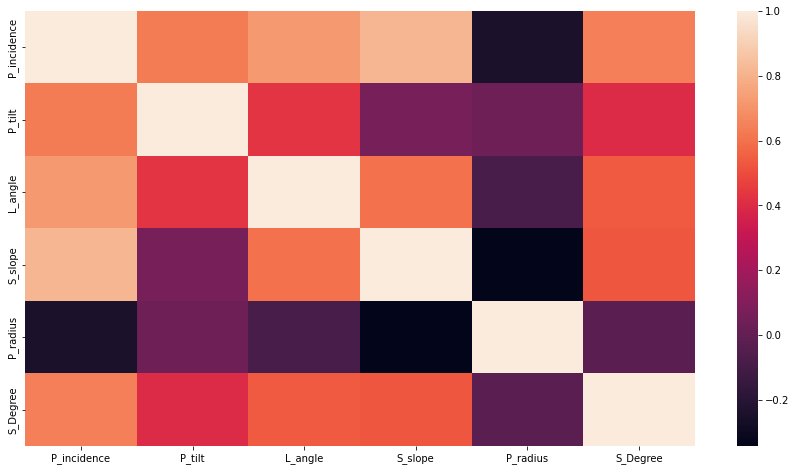

```python
plt.figure(figsize=(15,8))
sns.heatmap(corr)
```

### Part 1.3 b - Share insights on correlation

#### Features having stronger correlation with correlation value.

As we can see the strongest positive co-relation is between p_incidence and s_slope 0.814960

### Part 1.3 c - Visualize a pairplot with 3 classes distinguished by colors and share insights

```python
alldata[alldata.index.duplicated()] #sns pairplot not possible with duplicated values so finding it
```

|  | P_incidence | P_tilt | L_angle | S_slope | P_radius | S_Degree | Class |
| --- | --- | --- | --- | --- | --- | --- | --- |
| 0 | 63.027817 | 22.552586 | 39.609117 | 40.475232 | 98.672917 | -0.254400 | Type_H |
| 1 | 39.056951 | 10.060991 | 25.015378 | 28.995960 | 114.405425 | 4.564259 | Type_H |
| 2 | 68.832021 | 22.218482 | 50.092194 | 46.613539 | 105.985135 | -3.530317 | Type_H |
| 3 | 69.297008 | 24.652878 | 44.311238 | 44.644130 | 101.868495 | 11.211523 | Type_H |
| 4 | 49.712859 | 9.652075 | 28.317406 | 40.060784 | 108.168725 | 7.918501 | Type_H |
| ... | ... | ... | ... | ... | ... | ... | ... |
| 95 | 66.804796 | 14.551602 | 72.084912 | 52.253195 | 82.456038 | 41.685474 | Type_S |
| 96 | 79.476978 | 26.732268 | 70.650982 | 52.744711 | 118.588669 | 61.700598 | Type_S |
| 97 | 44.216464 | 1.507075 | 46.110339 | 42.709390 | 108.629567 | 42.810481 | Type_S |
| 98 | 57.035097 | 0.345728 | 49.198003 | 56.689369 | 103.048698 | 52.165145 | Type_S |
| 99 | 64.274818 | 12.508643 | 68.702377 | 51.766175 | 95.252454 | 39.409826 | Type_S |

160 rows × 7 columns

```python
alldata.reset_index(inplace=True) #solving the problem of duplicate item
```

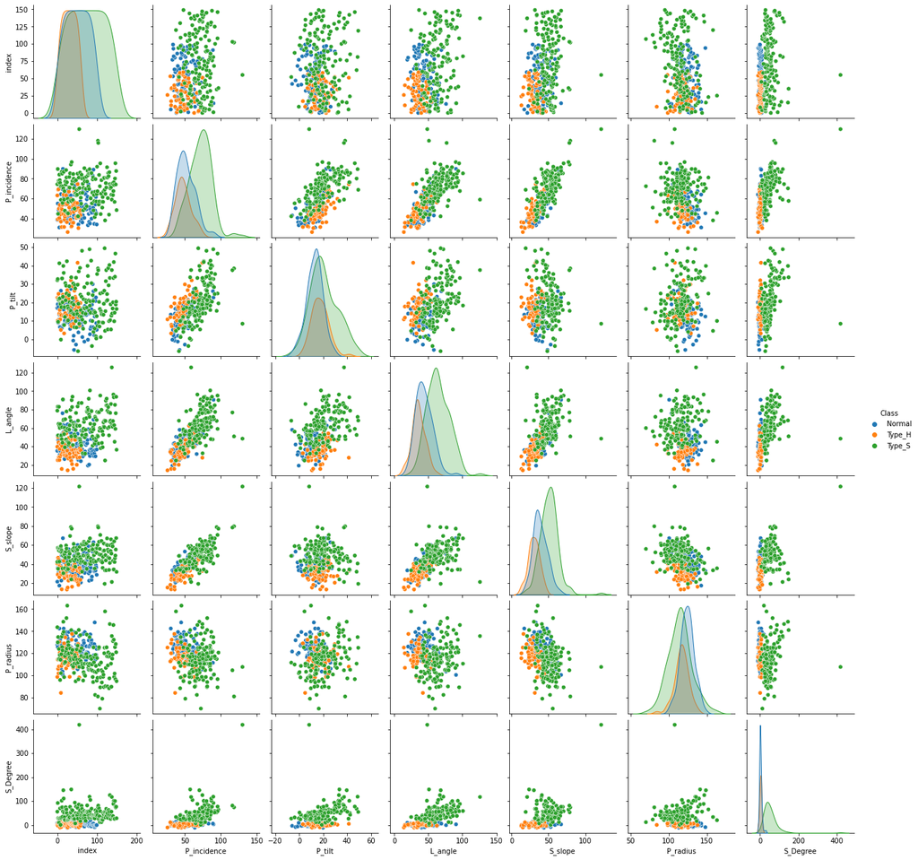

```python
sns.pairplot(alldata,hue='Class')
```

The Data population of Type_S is more than the Normal and Type_H

Distribution of classes are not same for Normal, Type_H and Type_S in daigonal. Its varying.

The regression will fit better between p_incidence and s_slope we can see the strong bond in graph

### Part 1.3 d - Visualize a jointplot for ‘P_incidence’ and ‘S_slope’ and share insights

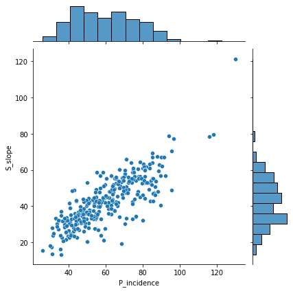

```python
sns.jointplot(x='P_incidence',y='S_slope',data=alldata)
```

The co-relation is strong maximum data population is between 4-80 for P_incidence and 20-70 for S_Slope

### Part 1.3 e - Visualize a boxplot to check distribution of the features and share insights.

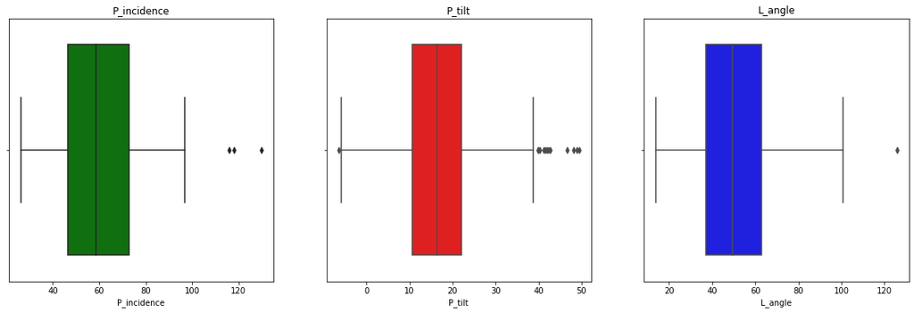

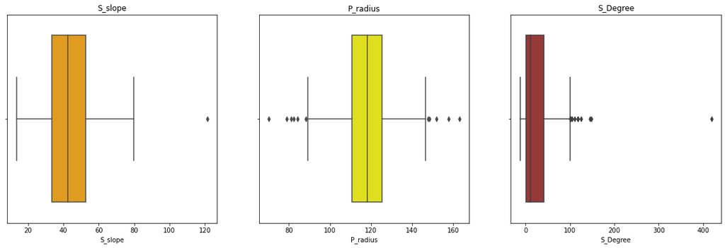

```python
plt.figure(figsize=(20,6))
plt.subplot(1, 3, 1)
plt.title('P_incidence')
sns.boxplot(alldata['P_incidence'],color='green')

plt.subplot(1, 3, 2)
plt.title('P_tilt')
sns.boxplot(alldata['P_tilt'],color='red')

plt.subplot(1, 3, 3)
plt.title('L_angle')
sns.boxplot(alldata['L_angle'],color='blue')

plt.figure(figsize=(20,6))
plt.subplot(1, 3, 1)
plt.title('S_slope')
sns.boxplot(alldata['S_slope'],color='orange')

plt.subplot(1, 3, 2)
plt.title('P_radius')
sns.boxplot(alldata['P_radius'],color='yellow')

plt.subplot(1, 3, 3)
plt.title('S_Degree')
sns.boxplot(alldata['S_Degree'],color='brown')
```

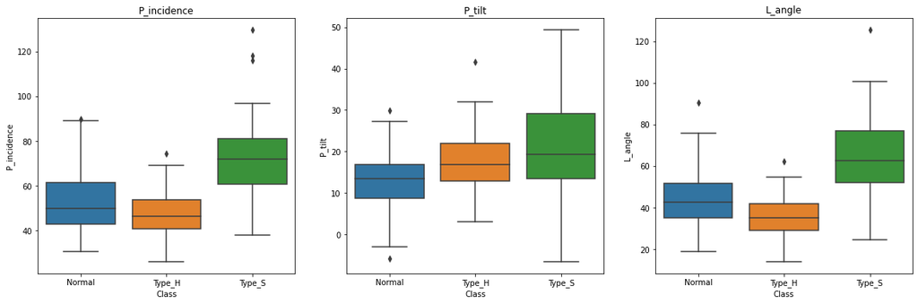

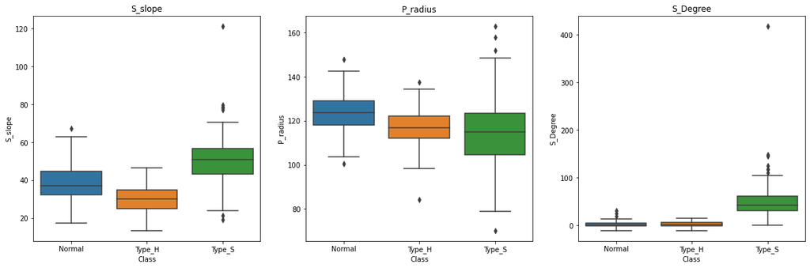

```python
plt.figure(figsize=(20,6))
plt.subplot(1, 3, 1)
plt.title('P_incidence')
sns.boxplot(data=alldata,y='P_incidence',x='Class')

plt.subplot(1, 3, 2)
plt.title('P_tilt')
sns.boxplot(data=alldata,y='P_tilt',x='Class')

plt.subplot(1, 3, 3)
plt.title('L_angle')
sns.boxplot(data=alldata,y='L_angle',x='Class')

plt.figure(figsize=(20,6))
plt.subplot(1, 3, 1)
plt.title('S_slope')
sns.boxplot(data=alldata,y='S_slope',x='Class')

plt.subplot(1, 3, 2)
plt.title('P_radius')
sns.boxplot(data=alldata,y='P_radius',x='Class')

plt.subplot(1, 3, 3)
plt.title('S_Degree')
sns.boxplot(data=alldata,y='S_Degree',x='Class')
```

p_tilt- range from -10 to 40 and median of 18. It has more outliers as compared to other features. Type_S and Type_H has higher p_tilt

L_angle- range from 12 to 105 and median of 50. It has one outlier. Type_S has higher L_angle than other type.

S_slope- range from 8 to 80 and median of 42. It has one outlier. Type_S again higher value than other.

S_Degree- range from 0 to 100 and median of 10. It has some outliers. Type_S has higher S_Degree.

# 1.4. Model Building & 1.5 Performance Improvement:

### Part 1.4 a - Split data into X and Y.

```python
from sklearn.preprocessing import LabelEncoder #Change all the classes to numericals (0to2)
class_label_encoder = LabelEncoder()

alldata.iloc[:,-1] = class_label_encoder.fit_transform(alldata.iloc[:,-1])
```

```python
alldata.head()
```

|  | index | P_incidence | P_tilt | L_angle | S_slope | P_radius | S_Degree | Class |
| --- | --- | --- | --- | --- | --- | --- | --- | --- |
| 0 | 0 | 38.505273 | 16.964297 | 35.112814 | 21.540976 | 127.632875 | 7.986683 | 0 |
| 1 | 1 | 54.920858 | 18.968430 | 51.601455 | 35.952428 | 125.846646 | 2.001642 | 0 |
| 2 | 2 | 44.362490 | 8.945435 | 46.902096 | 35.417055 | 129.220682 | 4.994195 | 0 |
| 3 | 3 | 48.318931 | 17.452121 | 48.000000 | 30.866809 | 128.980308 | -0.910941 | 0 |
| 4 | 4 | 45.701789 | 10.659859 | 42.577846 | 35.041929 | 130.178314 | -3.388910 | 0 |

```python
alldata.info()
```

```
<class 'pandas.core.frame.DataFrame'>
RangeIndex: 310 entries, 0 to 309
Data columns (total 8 columns):
 #   Column       Non-Null Count  Dtype
---  ------       --------------  -----
 0   index        310 non-null    int64
 1   P_incidence  310 non-null    float64
 2   P_tilt       310 non-null    float64
 3   L_angle      310 non-null    float64
 4   S_slope      310 non-null    float64
 5   P_radius     310 non-null    float64
 6   S_Degree     310 non-null    float64
 7   Class        310 non-null    int32
dtypes: float64(6), int32(1), int64(1)
memory usage: 18.3 KB
```

```python
X=alldata.drop(columns='Class')
y= alldata['Class']
```

### Part 1.4 b - Split data into train and test with 80:20 proportion

```python
from sklearn.model_selection import train_test_split
X_train, X_test, y_train, y_test = train_test_split(X, y, test_size=0.2, random_state=7)
```

```python
print(X_train.shape)
print(y_train.shape)
```

```
(248, 7)
(248,)
```

```python
print(X_test.shape)
print(y_test.shape)
```

```
(62, 7)
(62,)
```

### Part 1.4 c - Train a Supervised Learning Classification base model using KNN classifier &

### Part 1.5 a - Experiment with various parameters to improve performance of the base model

```python
# loading library
from sklearn.neighbors import KNeighborsClassifier
from sklearn.metrics import accuracy_score

# instantiate learning model (k = 3)
knn = KNeighborsClassifier(n_neighbors = 3)

# fitting the model
knn.fit(X_train, y_train)

# predict the response
y_pred = knn.predict(X_test)

# evaluate accuracy
print(accuracy_score(y_test, y_pred))




# instantiate learning model (k = 5)
knn = KNeighborsClassifier(n_neighbors=5)

# fitting the model
knn.fit(X_train, y_train)

# predict the response
y_pred = knn.predict(X_test)

# evaluate accuracy
print(accuracy_score(y_test, y_pred))






# instantiate learning model (k = 9)
knn = KNeighborsClassifier(n_neighbors=9)

# fitting the model
knn.fit(X_train, y_train)

# predict the response
y_pred = knn.predict(X_test)

# evaluate accuracy
print(accuracy_score(y_test, y_pred))
```

```
0.8225806451612904
0.8548387096774194
0.8387096774193549
```

### Part 1.5 b - Clearly showcase improvement in performance achieved &

### Part 1.5 c - Clearly state which parameters contributed most to improve model performance

```python
# instantiate learning model (k = 5)
knn = KNeighborsClassifier(n_neighbors=5)

# fitting the model
knn.fit(X_train, y_train)

# predict the response
y_pred = knn.predict(X_test)

# evaluate accuracy
print(accuracy_score(y_test, y_pred))
```

```
0.8548387096774194
```

the value of k=5 is the best for improving the performance of Model

### Part 1.4 d - Print all the possible performance metrics for both train and test data

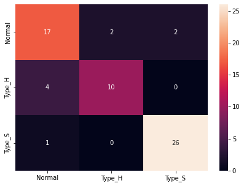

```python
# calculate accuracy measures and confusion matrix
from sklearn import metrics
from sklearn.metrics import confusion_matrix

cm = confusion_matrix(y_test, y_pred, labels=[0, 1,2])

df_cm = pd.DataFrame(cm, index = [i for i in ["Normal","Type_H","Type_S"]],
                  columns = [i for i in ["Normal","Type_H","Type_S"]])
plt.figure(figsize = (7,5))
sns.heatmap(df_cm, annot=True ,fmt='g')
plt.show()
```

```python
from sklearn.metrics import classification_report
print("classification  Matrix:\n",classification_report(y_test,y_pred))
```

```
classification  Matrix:
               precision    recall  f1-score   support

           0       0.77      0.81      0.79        21
           1       0.83      0.71      0.77        14
           2       0.93      0.96      0.95        27

    accuracy                           0.85        62
   macro avg       0.84      0.83      0.84        62
weighted avg       0.85      0.85      0.85        62
```

## Summary : 85% is best accuracy because the data population is not equally divided as we has noticed it during data visualization. The data population of "Type_S" is more than "normal" and "Type_h". This decreases the model accuracy.

# PART B

• DOMAIN: Banking, Marketing

• CONTEXT: A bank X is on a massive digital transformation for all its departments. Bank has a growing customer base whee majority of them are liability customers (depositors) vs borrowers (asset customers). The bank is interested in expanding the borrowers base rapidly to bring in more business via loan interests. A campaign that the bank ran in last quarter showed an average single digit conversion rate. Digital transformation being the core strength of the business strategy, marketing department wants to devise effective campaigns with better target marketing to increase the conversion ratio to double digit with same budget as per last campaign.

• DATA DICTIONARY:

1. Team: Team’s name
2. ID: Customer ID
3. Age: Customer’s approximate age.
4. CustomerSince: Customer of the bank since. [unit is masked]
5. HighestSpend: Customer’s highest spend so far in one transaction. [unit is masked]
6. ZipCode: Customer’s zip code.
7. HiddenScore: A score associated to the customer which is masked by the bank as an IP.
8. MonthlyAverageSpend: Customer’s monthly average spend so far. [unit is masked]
9. Level: A level associated to the customer which is masked by the bank as an IP.
10. Mortgage: Customer’s mortgage. [unit is masked]
11. Security: Customer’s security asset with the bank. [unit is masked]
12. FixedDepositAccount: Customer’s fixed deposit account with the bank. [unit is masked]
13. InternetBanking: if the customer uses internet banking.
14. CreditCard: if the customer uses bank’s credit card.
15. LoanOnCard: if the customer has a loan on credit card.

• PROJECT OBJECTIVE: Build a Machine Learning model to perform focused marketing by predicting the potential customers who will convert using the historical dataset.

# 2.1 Data Understanding and Preparation:

### Part 2.1 a - Read both the Datasets ‘Data1’ and ‘Data 2’ as DataFrame and store them into two separate variables

```python
import pandas as pd
import numpy as np
import matplotlib.pyplot as plt
%matplotlib inline
import seaborn as sns
```

```python
bank1= pd.read_csv("Data1.csv")
bank2= pd.read_csv("Data2.csv")
```

### Part 2.1 b - Print shape and Column Names and DataTypes of both the Dataframes.

```python
print("The size of Data1 is {}".format(bank1.shape))
print("The size of Data2 is {}".format(bank2.shape))
```

```
The size of Data1 is (5000, 8)
The size of Data2 is (5000, 7)
```

```python
print("The columns of Data1 is {}".format(bank1.columns))
print("The columns of Data2 is {}".format(bank2.columns))
```

```
The columns of Data1 is Index(['ID', 'Age', 'CustomerSince', 'HighestSpend', 'ZipCode', 'HiddenScore',
       'MonthlyAverageSpend', 'Level'],
      dtype='object')
The columns of Data2 is Index(['ID', 'Mortgage', 'Security', 'FixedDepositAccount', 'InternetBanking',
       'CreditCard', 'LoanOnCard'],
      dtype='object')
```

```python
print("The DataTypes of Data1 is {}".format(bank1.dtypes))
print("The DataTypes of Data2 is {}".format(bank2.dtypes))
```

```
The DataTypes of Data1 is ID                       int64
Age                      int64
CustomerSince            int64
HighestSpend             int64
ZipCode                  int64
HiddenScore              int64
MonthlyAverageSpend    float64
Level                    int64
dtype: object
The DataTypes of Data2 is ID                       int64
Mortgage                 int64
Security                 int64
FixedDepositAccount      int64
InternetBanking          int64
CreditCard               int64
LoanOnCard             float64
dtype: object
```

### Part 2.1 c - Merge both the Dataframes on ‘ID’ feature to form a single DataFrame

```python
bankdata = pd.merge(bank1, bank2, how='inner', left_on = 'ID', right_on = 'ID')
```

```python
bankdata.head()
```

|  | ID | Age | CustomerSince | HighestSpend | ZipCode | HiddenScore | MonthlyAverageSpend | Level | Mortgage | Security | FixedDepositAccount | InternetBanking | CreditCard | LoanOnCard |
| --- | --- | --- | --- | --- | --- | --- | --- | --- | --- | --- | --- | --- | --- | --- |
| 0 | 1 | 25 | 1 | 49 | 91107 | 4 | 1.6 | 1 | 0 | 1 | 0 | 0 | 0 | NaN |
| 1 | 2 | 45 | 19 | 34 | 90089 | 3 | 1.5 | 1 | 0 | 1 | 0 | 0 | 0 | NaN |
| 2 | 3 | 39 | 15 | 11 | 94720 | 1 | 1.0 | 1 | 0 | 0 | 0 | 0 | 0 | NaN |
| 3 | 4 | 35 | 9 | 100 | 94112 | 1 | 2.7 | 2 | 0 | 0 | 0 | 0 | 0 | NaN |
| 4 | 5 | 35 | 8 | 45 | 91330 | 4 | 1.0 | 2 | 0 | 0 | 0 | 0 | 1 | NaN |

```python
bankdata.info()
```

```
<class 'pandas.core.frame.DataFrame'>
Int64Index: 5000 entries, 0 to 4999
Data columns (total 14 columns):
 #   Column               Non-Null Count  Dtype
---  ------               --------------  -----
 0   ID                   5000 non-null   int64
 1   Age                  5000 non-null   int64
 2   CustomerSince        5000 non-null   int64
 3   HighestSpend         5000 non-null   int64
 4   ZipCode              5000 non-null   int64
 5   HiddenScore          5000 non-null   int64
 6   MonthlyAverageSpend  5000 non-null   float64
 7   Level                5000 non-null   int64
 8   Mortgage             5000 non-null   int64
 9   Security             5000 non-null   int64
 10  FixedDepositAccount  5000 non-null   int64
 11  InternetBanking      5000 non-null   int64
 12  CreditCard           5000 non-null   int64
 13  LoanOnCard           4980 non-null   float64
dtypes: float64(2), int64(12)
memory usage: 585.9 KB
```

```python
bankdata.isna().sum()
```

```
ID                      0
Age                     0
CustomerSince           0
HighestSpend            0
ZipCode                 0
HiddenScore             0
MonthlyAverageSpend     0
Level                   0
Mortgage                0
Security                0
FixedDepositAccount     0
InternetBanking         0
CreditCard              0
LoanOnCard             20
dtype: int64
```

```python
ax=bankdata.duplicated()
print("The duplicare row {}".format(ax==True))
```

```
The duplicare row 0       False
1       False
2       False
3       False
4       False
        ...
4995    False
4996    False
4997    False
4998    False
4999    False
Length: 5000, dtype: bool
```

### Part 2.1 d - Change Datatype of below features to ‘Object’

```python
bankdata['CreditCard']=bankdata['CreditCard'].astype('category')
bankdata['InternetBanking']=bankdata['InternetBanking'].astype('category')
bankdata['FixedDepositAccount']=bankdata['FixedDepositAccount'].astype('category')
bankdata['Security']=bankdata['Security'].astype('category')
bankdata['Level']=bankdata['Level'].astype('category')
bankdata['HiddenScore']=bankdata['HiddenScore'].astype('category')
```

# 2.2 Data Exploration and Analysis:

### Part 2.2 a - Visualize distribution of Target variable ‘LoanOnCard’ and clearly share insights

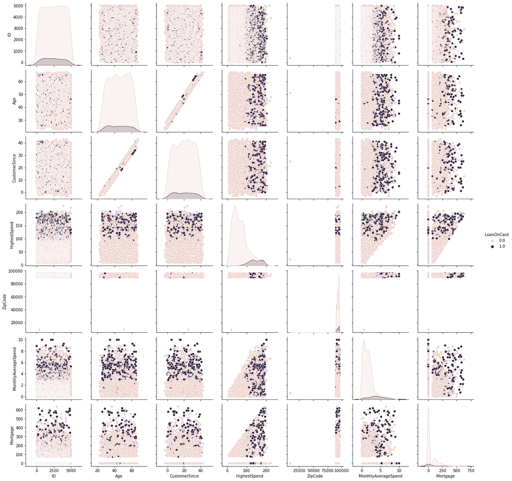

```python
sns.pairplot(bankdata,hue='LoanOnCard')
```

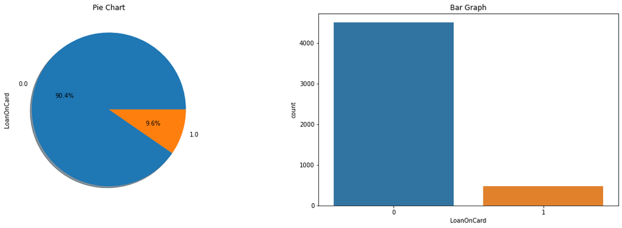

```python
f,axes=plt.subplots(1,2,figsize=(20,6))
bankdata['LoanOnCard'].value_counts().plot.pie(autopct='%1.1f%%',ax=axes[0],shadow=True)
sns.countplot('LoanOnCard',data=bankdata,ax=axes[1],order=[0,1])
axes[0].set_title('Pie Chart')
axes[1].set_title('Bar Graph')
plt.show()
```

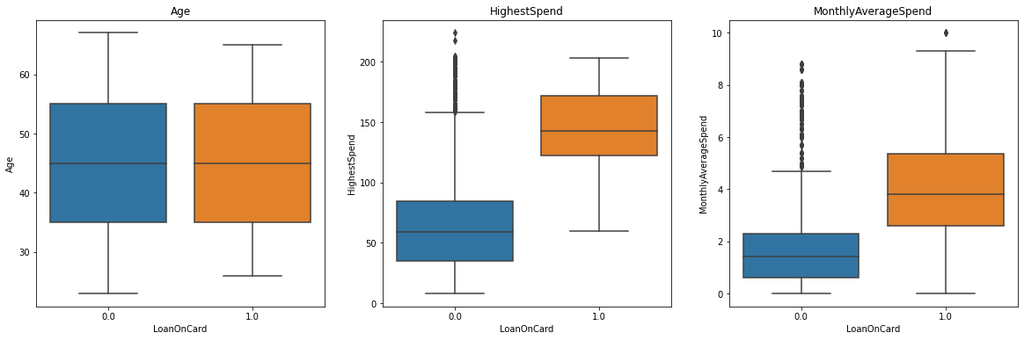

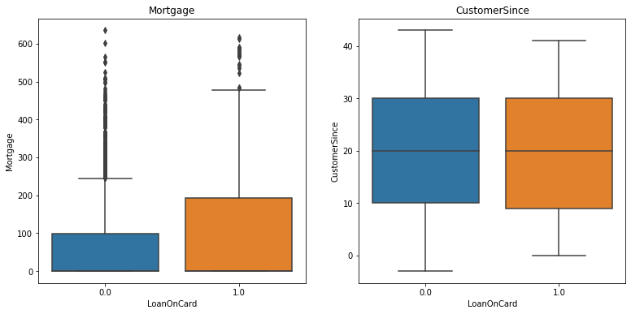

```python
plt.figure(figsize=(20,6))
plt.subplot(1, 3, 1)
plt.title('Age')
sns.boxplot(data=bankdata,y='Age',x='LoanOnCard')

plt.subplot(1, 3, 2)
plt.title('HighestSpend')
sns.boxplot(data=bankdata,y='HighestSpend',x='LoanOnCard')

plt.subplot(1, 3, 3)
plt.title('MonthlyAverageSpend')
sns.boxplot(data=bankdata,y='MonthlyAverageSpend',x='LoanOnCard')

plt.figure(figsize=(20,6))
plt.subplot(1, 3, 1)
plt.title('Mortgage')
sns.boxplot(data=bankdata,y='Mortgage',x='LoanOnCard')


plt.subplot(1, 3, 2)
plt.title('CustomerSince')
sns.boxplot(data=bankdata,y='CustomerSince',x='LoanOnCard')
```

9.6% have got loan

The median of Highest spender has got loan as its median is quite ahead

The Outliers is more in Mortage, Highest Spend and Monthly/Average Spend

It minimises the risk of default but also decreasing the Profit fold of company

### Part 2.2 b - Check the percentage of missing values and impute if required &

### Part 2.2 c - Check for unexpected values in each categorical variable and impute with best suitable value.

```python
bankdata.isnull().sum()
```

```
ID                      0
Age                     0
CustomerSince           0
HighestSpend            0
ZipCode                 0
HiddenScore             0
MonthlyAverageSpend     0
Level                   0
Mortgage                0
Security                0
FixedDepositAccount     0
InternetBanking         0
CreditCard              0
LoanOnCard             20
dtype: int64
```

```python
bankdata.isnull().values.any()
```

```
True
```

```python
bankdata_df = bankdata.dropna(axis=0)
bankdata_df
```

|  | ID | Age | CustomerSince | HighestSpend | ZipCode | HiddenScore | MonthlyAverageSpend | Level | Mortgage | Security | FixedDepositAccount | InternetBanking | CreditCard | LoanOnCard |
| --- | --- | --- | --- | --- | --- | --- | --- | --- | --- | --- | --- | --- | --- | --- |
| 9 | 10 | 34 | 9 | 180 | 93023 | 1 | 8.9 | 3 | 0 | 0 | 0 | 0 | 0 | 1.0 |
| 10 | 11 | 65 | 39 | 105 | 94710 | 4 | 2.4 | 3 | 0 | 0 | 0 | 0 | 0 | 0.0 |
| 11 | 12 | 29 | 5 | 45 | 90277 | 3 | 0.1 | 2 | 0 | 0 | 0 | 1 | 0 | 0.0 |
| 12 | 13 | 48 | 23 | 114 | 93106 | 2 | 3.8 | 3 | 0 | 1 | 0 | 0 | 0 | 0.0 |
| 13 | 14 | 59 | 32 | 40 | 94920 | 4 | 2.5 | 2 | 0 | 0 | 0 | 1 | 0 | 0.0 |
| ... | ... | ... | ... | ... | ... | ... | ... | ... | ... | ... | ... | ... | ... | ... |
| 4995 | 4996 | 29 | 3 | 40 | 92697 | 1 | 1.9 | 3 | 0 | 0 | 0 | 1 | 0 | 0.0 |
| 4996 | 4997 | 30 | 4 | 15 | 92037 | 4 | 0.4 | 1 | 85 | 0 | 0 | 1 | 0 | 0.0 |
| 4997 | 4998 | 63 | 39 | 24 | 93023 | 2 | 0.3 | 3 | 0 | 0 | 0 | 0 | 0 | 0.0 |
| 4998 | 4999 | 65 | 40 | 49 | 90034 | 3 | 0.5 | 2 | 0 | 0 | 0 | 1 | 0 | 0.0 |
| 4999 | 5000 | 28 | 4 | 83 | 92612 | 3 | 0.8 | 1 | 0 | 0 | 0 | 1 | 1 | 0.0 |

4980 rows × 14 columns

```python
bankdata_df.isna().sum()
```

```
ID                     0
Age                    0
CustomerSince          0
HighestSpend           0
ZipCode                0
HiddenScore            0
MonthlyAverageSpend    0
Level                  0
Mortgage               0
Security               0
FixedDepositAccount    0
InternetBanking        0
CreditCard             0
LoanOnCard             0
dtype: int64
```

```python
bankdata_df.isnull().values.any()
```

```
False
```

```python
bankdata_df.info()
```

```
<class 'pandas.core.frame.DataFrame'>
Int64Index: 4980 entries, 9 to 4999
Data columns (total 14 columns):
 #   Column               Non-Null Count  Dtype
---  ------               --------------  -----
 0   ID                   4980 non-null   int64
 1   Age                  4980 non-null   int64
 2   CustomerSince        4980 non-null   int64
 3   HighestSpend         4980 non-null   int64
 4   ZipCode              4980 non-null   int64
 5   HiddenScore          4980 non-null   category
 6   MonthlyAverageSpend  4980 non-null   float64
 7   Level                4980 non-null   category
 8   Mortgage             4980 non-null   int64
 9   Security             4980 non-null   category
 10  FixedDepositAccount  4980 non-null   category
 11  InternetBanking      4980 non-null   category
 12  CreditCard           4980 non-null   category
 13  LoanOnCard           4980 non-null   float64
dtypes: category(6), float64(2), int64(6)
memory usage: 380.1 KB
```

```python
n_true= len(bankdata_df.loc[bankdata_df['LoanOnCard']==True])
n_false= len(bankdata_df.loc[bankdata_df['LoanOnCard']==False])
print("Number of Loan True cases : {0} ({1:2.2f}%)" .format(n_true, (n_true/(n_true + n_false))*100))
print("Number of Loan False cases: {0}({1:2.2f}%)". format(n_false,(n_false/(n_true + n_false))*100))
```

```
Number of Loan True cases : 480 (9.64%)
Number of Loan False cases: 4500(90.36%)
```

```python
bankdata_df.drop('ID',axis=1,inplace=True) #dropping ID as its not that important for Regression
```

```python
bankdata_df
```

|  | Age | CustomerSince | HighestSpend | ZipCode | HiddenScore | MonthlyAverageSpend | Level | Mortgage | Security | FixedDepositAccount | InternetBanking | CreditCard | LoanOnCard |
| --- | --- | --- | --- | --- | --- | --- | --- | --- | --- | --- | --- | --- | --- |
| 9 | 34 | 9 | 180 | 93023 | 1 | 8.9 | 3 | 0 | 0 | 0 | 0 | 0 | 1.0 |
| 10 | 65 | 39 | 105 | 94710 | 4 | 2.4 | 3 | 0 | 0 | 0 | 0 | 0 | 0.0 |
| 11 | 29 | 5 | 45 | 90277 | 3 | 0.1 | 2 | 0 | 0 | 0 | 1 | 0 | 0.0 |
| 12 | 48 | 23 | 114 | 93106 | 2 | 3.8 | 3 | 0 | 1 | 0 | 0 | 0 | 0.0 |
| 13 | 59 | 32 | 40 | 94920 | 4 | 2.5 | 2 | 0 | 0 | 0 | 1 | 0 | 0.0 |
| ... | ... | ... | ... | ... | ... | ... | ... | ... | ... | ... | ... | ... | ... |
| 4995 | 29 | 3 | 40 | 92697 | 1 | 1.9 | 3 | 0 | 0 | 0 | 1 | 0 | 0.0 |
| 4996 | 30 | 4 | 15 | 92037 | 4 | 0.4 | 1 | 85 | 0 | 0 | 1 | 0 | 0.0 |
| 4997 | 63 | 39 | 24 | 93023 | 2 | 0.3 | 3 | 0 | 0 | 0 | 0 | 0 | 0.0 |
| 4998 | 65 | 40 | 49 | 90034 | 3 | 0.5 | 2 | 0 | 0 | 0 | 1 | 0 | 0.0 |
| 4999 | 28 | 4 | 83 | 92612 | 3 | 0.8 | 1 | 0 | 0 | 0 | 1 | 1 | 0.0 |

4980 rows × 13 columns

### As observed in Boxplot visulalization the Outliers is more in 'HighestSpend','MonthlyAverageSpend'and 'Mortgage'. This will hit the model accuracy. So lets treat it.

```python
col=['HighestSpend','MonthlyAverageSpend','Mortgage']
for c in col:
    #getting upper lower quartile values
    q25,q75=np.percentile(bankdata_df[c],25),np.percentile(bankdata_df[c],75)
    IQR=q75-q25
    Threshold=IQR*1.5
    lower,upper=q25-Threshold,q75+Threshold
    Outliers=[i for i in bankdata_df[c] if i < lower or i > upper]
    print('{} Total Number of outliers in {} Before Imputing : {}'.format('\033[1m',c,len(Outliers)))
    print('\n')
    #taking mean of a column without considering outliers
    bankdata_df_include = bankdata_df.loc[(bankdata_df[c] >= lower) & (bankdata_df[c] <= upper)]
    mean=int(bankdata_df_include[c].mean())
    print('{} Mean of {} is {}'.format('\033[1m',c,mean))
    print('\n')
    #imputing outliers with mean
    bankdata_df[c]=np.where(bankdata_df[c]>upper,mean,bankdata_df[c])
    bankdata_df[c]=np.where(bankdata_df[c]<lower,mean,bankdata_df[c])
    Outliers=[i for i in bankdata_df[c] if i < lower or i > upper]
    print('{} Total Number of outliers in {} After Imputing : {}'.format('\033[1m',c,len(Outliers)))
    print('\n')
```

```
 Total Number of outliers in HighestSpend Before Imputing : 96


 Mean of HighestSpend is 71


 Total Number of outliers in HighestSpend After Imputing : 0


 Total Number of outliers in MonthlyAverageSpend Before Imputing : 324


 Mean of MonthlyAverageSpend is 1


 Total Number of outliers in MonthlyAverageSpend After Imputing : 0


 Total Number of outliers in Mortgage Before Imputing : 291


 Mean of Mortgage is 38


 Total Number of outliers in Mortgage After Imputing : 0
```

# 2.3 Data Preparation and model building:

### Part 2.3 a- Split data into X and Y

```python
bankdata_df.drop(columns=["ZipCode"],inplace=True)
```

```python
X= bankdata_df.drop(columns=["LoanOnCard"])
y= bankdata_df[['LoanOnCard']]
```

### Part 2.3 b - Split data into train and test. Keep 25% data reserved for testing

```python
from sklearn.model_selection import train_test_split
X_train,X_test,y_train,y_test= train_test_split(X,y,test_size=0.25,random_state=12)
```

```python
X_train.shape
```

```
(3735, 11)
```

```python
X_test.shape
```

```
(1245, 11)
```

### Part 2.3 c - Train a Supervised Learning Classification base model - Logistic Regression

```python
from sklearn.linear_model import LogisticRegression
Logi_bank_model= LogisticRegression()
Logi_bank_model.fit(X_train,y_train)
Logi_bank_predict= Logi_bank_model.predict(X_test)

print("The accuracy of Logistic Training set {}".format(Logi_bank_model.score(X_train,y_train)))
print()
print("The accuracy of Logistic Test set {}".format(Logi_bank_model.score(X_test,y_test)))
```

```
The accuracy of Logistic Training set 0.9520749665327979

The accuracy of Logistic Test set 0.940562248995984
```

### Part 2.3 d - Print evaluation metrics for the model and clearly share insights.

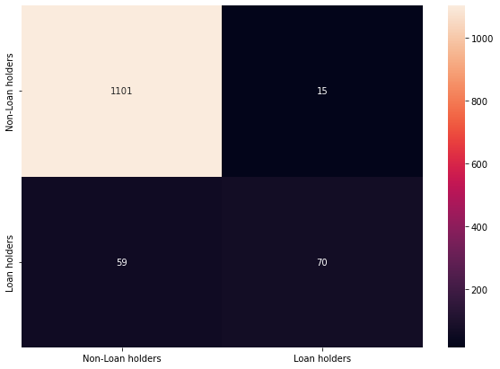

```python
from sklearn import metrics
from sklearn.metrics import confusion_matrix



cm = confusion_matrix(y_test, Logi_bank_predict, labels=[0, 1])

bank_cm = pd.DataFrame(cm, index = [i for i in ["Non-Loan holders","Loan holders"]],
                  columns = [i for i in ["Non-Loan holders","Loan holders"]])
plt.figure(figsize = (10,7))
sns.heatmap(bank_cm, annot=True ,fmt='g')
plt.show()
```

```python
from sklearn.metrics import classification_report
print("classification  Matrix:\n",classification_report(y_test,Logi_bank_predict))
```

```
classification  Matrix:
               precision    recall  f1-score   support

         0.0       0.95      0.99      0.97      1116
         1.0       0.82      0.54      0.65       129

    accuracy                           0.94      1245
   macro avg       0.89      0.76      0.81      1245
weighted avg       0.94      0.94      0.94      1245
```

By removing outliers the accuracy of model for type 2 error has been erupted. Sometimes it is advised to model with outlier the accuracy will increase but type 1 error might increase also type 2 error will decrease. !!

### Part 2.3 e - Balance the data using the right balancing technique.

```python
X.head()
```

|  | Age | CustomerSince | HighestSpend | HiddenScore | MonthlyAverageSpend | Level | Mortgage | Security | FixedDepositAccount | InternetBanking | CreditCard |
| --- | --- | --- | --- | --- | --- | --- | --- | --- | --- | --- | --- |
| 9 | 34 | 9 | 180 | 1 | 1.0 | 3 | 0 | 0 | 0 | 0 | 0 |
| 10 | 65 | 39 | 105 | 4 | 2.4 | 3 | 0 | 0 | 0 | 0 | 0 |
| 11 | 29 | 5 | 45 | 3 | 0.1 | 2 | 0 | 0 | 0 | 1 | 0 |
| 12 | 48 | 23 | 114 | 2 | 3.8 | 3 | 0 | 1 | 0 | 0 | 0 |
| 13 | 59 | 32 | 40 | 4 | 2.5 | 2 | 0 | 0 | 0 | 1 | 0 |

```python
y.head()
```

|  | LoanOnCard |
| --- | --- |
| 9 | 1.0 |
| 10 | 0.0 |
| 11 | 0.0 |
| 12 | 0.0 |
| 13 | 0.0 |

```python
from imblearn.over_sampling import RandomOverSampler
from imblearn.over_sampling import SMOTENC
from imblearn.over_sampling import SMOTE

sm = SMOTE(random_state=42, sampling_strategy='minority') #because we aredoing it for minority data
X_train_2, y_train_2 = sm.fit_resample(X,y)

#Before Oversampling
unique,counts = np.unique (y_train, return_counts = True)
print(np.asarray((unique,counts)).T)

#After Oversampling
unique,counts = np.unique(y_train_2, return_counts= True)
print(np.asarray((unique,counts)).T)
```

```
[[0.000e+00 3.384e+03]
 [1.000e+00 3.510e+02]]
[[0.0e+00 4.5e+03]
 [1.0e+00 4.5e+03]]
```

### Part 2.3 f- Again train the same previous model on balanced data

```python
X_train, X_test, y_train, y_test = train_test_split(X_train_2, y_train_2, test_size=0.25, random_state=12)
```

```python
X_train.dropna
```

[output not shown]

```python
#X_train = X_train.replace((np.inf, -np.inf, np.nan), 0).reset_index(drop=True)
```

```python
Logi_bank_model= LogisticRegression()
Logi_bank_model.fit(X_train,y_train)
Logi_bank_predict= Logi_bank_model.predict(X_test)

print("The accuracy of Logistic Training set {}".format(Logi_bank_model.score(X_train,y_train)))
print()
print("The accuracy of Logistic Test set {}".format(Logi_bank_model.score(X_test,y_test)))
```

[output not shown]

### Part 2.3 g- Print evaluation metrics and clearly share differences observed

[figure not shown]

```python
from sklearn import metrics
from sklearn.metrics import confusion_matrix



cm = confusion_matrix(y_test, Logi_bank_predict, labels=[0, 1])

bank_cm = pd.DataFrame(cm, index = [i for i in ["Non-Loan holders","Loan holders"]],
                  columns = [i for i in ["Non-Loan holders","Loan holders"]])
plt.figure(figsize = (10,7))
sns.heatmap(bank_cm, annot=True ,fmt='g')
plt.show()
```

```python
print("classification  Matrix:\n",classification_report(y_test,Logi_bank_predict))
```

[output not shown]

# 2.4 Performance Improvement

### Part 2.4 a- Train a base model each for SVM, KNN

### Part 2.4 b - Tune parameters for each of the models wherever required and finalize a mode

### Part 2.4 c- Print evaluation metrics for final mode

### FOR KNN

```python
X.info()
y.info()
```

```
<class 'pandas.core.frame.DataFrame'>
Int64Index: 4980 entries, 9 to 4999
Data columns (total 11 columns):
 #   Column               Non-Null Count  Dtype
---  ------               --------------  -----
 0   Age                  4980 non-null   int64
 1   CustomerSince        4980 non-null   int64
 2   HighestSpend         4980 non-null   int64
 3   HiddenScore          4980 non-null   category
 4   MonthlyAverageSpend  4980 non-null   float64
 5   Level                4980 non-null   category
 6   Mortgage             4980 non-null   int64
 7   Security             4980 non-null   category
 8   FixedDepositAccount  4980 non-null   category
 9   InternetBanking      4980 non-null   category
 10  CreditCard           4980 non-null   category
dtypes: category(6), float64(1), int64(4)
memory usage: 263.4 KB
<class 'pandas.core.frame.DataFrame'>
Int64Index: 4980 entries, 9 to 4999
Data columns (total 1 columns):
 #   Column      Non-Null Count  Dtype
---  ------      --------------  -----
 0   LoanOnCard  4980 non-null   float64
dtypes: float64(1)
memory usage: 77.8 KB
```

```python
X_train, X_test, y_train, y_test = train_test_split(X, y, test_size=0.25, random_state=1)
```

```python
# instantiate learning model (k = 3)
knn = KNeighborsClassifier(n_neighbors = 3)

# fitting the model
knn.fit(X_train, y_train)

# predict the response
y_pred = knn.predict(X_test)

# evaluate accuracy
print(accuracy_score(y_test, y_pred))




# instantiate learning model (k = 5)
knn = KNeighborsClassifier(n_neighbors=5)

# fitting the model
knn.fit(X_train, y_train)

# predict the response
y_pred = knn.predict(X_test)

# evaluate accuracy
print(accuracy_score(y_test, y_pred))






# instantiate learning model (k = 9)
knn = KNeighborsClassifier(n_neighbors=9)

# fitting the model
knn.fit(X_train, y_train)

# predict the response
y_pred = knn.predict(X_test)

# evaluate accuracy
print(accuracy_score(y_test, y_pred))
```

```
0.8931726907630522
0.9020080321285141
0.9020080321285141
```

```python
# instantiate learning model (k = 5)
knn = KNeighborsClassifier(n_neighbors=5)

# fitting the model
knn.fit(X_train, y_train)

# predict the response
y_pred = knn.predict(X_test)

# evaluate accuracy
print(accuracy_score(y_test, y_pred))
```

```
0.9020080321285141
```

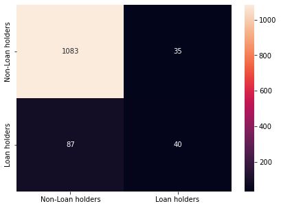

```python
cm = confusion_matrix(y_test, y_pred, labels=[0, 1])

df_cm = pd.DataFrame(cm, index = [i for i in ["Non-Loan holders","Loan holders"]],
                  columns = [i for i in ["Non-Loan holders","Loan holders"]])
plt.figure(figsize = (7,5))
sns.heatmap(df_cm, annot=True ,fmt='g')
plt.show()
```

```python
from sklearn.metrics import classification_report
print("classification  Matrix:\n",classification_report(y_test,y_pred))
```

```
classification  Matrix:
               precision    recall  f1-score   support

         0.0       0.93      0.97      0.95      1118
         1.0       0.53      0.31      0.40       127

    accuracy                           0.90      1245
   macro avg       0.73      0.64      0.67      1245
weighted avg       0.89      0.90      0.89      1245
```

### FOR SVM

```python
from sklearn.svm import SVC

svc = SVC()
svc.fit(X_train, y_train)

print("Accuracy on training set: {:}".format(svc.score(X_train, y_train)))
print("Accuracy on test set: {:}".format(svc.score(X_test, y_test)))
```

```
Accuracy on training set: 0.9054886211512717
Accuracy on test set: 0.8979919678714859
```

```python
svc2 = SVC(gamma=0.025, C=3)
svc.fit(X_train, y_train)

print("Accuracy on training set: {:}".format(svc.score(X_train, y_train)))
print("Accuracy on test set: {:}".format(svc.score(X_test, y_test)))
```

```
Accuracy on training set: 0.9054886211512717
Accuracy on test set: 0.8979919678714859
```

```python
clf = SVC(gamma=0.025, C=3)
clf.fit(X_train , y_train)
y_pred = clf.predict(X_test)
```

[figure not shown]

```python
cm = confusion_matrix(y_test, y_pred, labels=[0, 1])

df_cm = pd.DataFrame(cm, index = [i for i in ["Non-Loan holders","Loan holders"]],
                  columns = [i for i in ["Non-Loan holders","Loan holders"]])
plt.figure(figsize = (7,5))
sns.heatmap(df_cm, annot=True ,fmt='g')
plt.show()
```

```python
from sklearn.metrics import classification_report
print("classification  Matrix:\n",classification_report(y_test,y_pred))
```

[output not shown]

```python
from sklearn.preprocessing import MinMaxScaler

scaler = MinMaxScaler()
X_train_scaled = scaler.fit_transform(X_train)
X_test_scaled = scaler.fit_transform(X_test)
```

```python
svc = SVC(C=1000)
svc.fit(X_train_scaled, y_train)

print("Accuracy on training set: {:.3f}".format(
    svc.score(X_train_scaled, y_train)))
print("Accuracy on test set: {:.3f}".format(svc.score(X_test_scaled, y_test)))
```

```
Accuracy on training set: 0.997
Accuracy on test set: 0.966
```

### Part 2.4 d- Share improvement achieved from base model to final model

For Logistic Regression Model the accuracy and Performance is best if model is simple

But With 97% the Tuned SVM has high accuracy

Smote balances the model but adds noise. The accuracy is not that affecting.

In other models for Knn the accuracy of model is moderate with(k=5) and further increasing in SVM after tuning the data.

The Smote is adding more noise so have to treat the data after that. So always lookout the data after doing SMOTE and Z-Transform.

Warning option should be on to let know what future aspect changes you have to learn or add in program.